# ML Final Project

Fang Yuan

July 31, 2016

## Data prepare

Read in data:

```r
library(caret)
```

```r
library(randomForest)
library(gbm)
train <- read.csv("https://d396qusza40orc.cloudfront.net/predmachlearn/pml-training.csv")
test <- read.csv("https://d396qusza40orc.cloudfront.net/predmachlearn/pml-testing.csv")
```

Remove the variables that have 60% and above of NAs or missing values, and remove redundant variables. Variables like X and user_name won’t contribute to the model, so we remove them as well.

```r
trainsub1 <-train[sapply(train, function(x){
    length(unique(x)) > 1 & sum(is.na(x)|x=="") <= 0.6*nrow(train)
})]
trainsub2 <- trainsub1[,-(1:2)]
```

In unsupervised learning, variables that doesn’t have too much variability doesn’t contribute too much to the model. So we remove variables that have one level more then 95% of all the values.

```r
perc <- sapply(trainsub2, function(x){
    max(table(x)/nrow(trainsub2))
})
perc[order(perc, decreasing = TRUE)][1:10]
```

```
##       new_window           classe     gyros_belt_y total_accel_belt
##        0.9793089        0.2843747        0.2404954        0.2204668
##     roll_forearm    pitch_forearm      yaw_forearm        pitch_arm
##        0.1984507        0.1983998        0.1983488        0.1734278
##         roll_arm          yaw_arm
##        0.1733768        0.1733768
```

```r
trainsub <- trainsub2[,-which(colnames(trainsub2)=="new_window")]
```

We see that besides new_window, other variables all have property varibility. We drop new_window.

## Create training and test dataset

```r
inTrain <- createDataPartition(y=trainsub$classe, p=0.7, list=FALSE)
training <- trainsub[inTrain,]
testing <- trainsub[-inTrain,]
dim(training); dim(testing);
```

```
## [1] 13737    57
```

```
## [1] 5885   57
```

## Model training

```r
treefit <- train(classe ~ ., method="rpart", data=training)
print(treefit$finalModel)
```

```
## n= 13737
##
## node), split, n, loss, yval, (yprob)
##       * denotes terminal node
##
##    1) root 13737 9831 A (0.28 0.19 0.17 0.16 0.18)
##      2) roll_belt< 130.5 12568 8668 A (0.31 0.21 0.19 0.18 0.11)
##        4) pitch_forearm< -33.05 1104   15 A (0.99 0.014 0 0 0) *
##        5) pitch_forearm>=-33.05 11464 8653 A (0.25 0.23 0.21 0.2 0.12)
##         10) cvtd_timestamp02/12/2011 13:33>=0.5 903  224 A (0.75 0.25 0 0 0) *
##         11) cvtd_timestamp02/12/2011 13:33< 0.5 10561 8142 B (0.2 0.23 0.23 0.21 0.13)
##           22) magnet_dumbbell_z< -93.5 1335  536 A (0.6 0.29 0.04 0.053 0.022) *
##           23) magnet_dumbbell_z>=-93.5 9226 6884 C (0.14 0.22 0.25 0.24 0.14)
##             46) raw_timestamp_part_1< 1.32249e+09 376    0 A (1 0 0 0 0) *
##             47) raw_timestamp_part_1>=1.32249e+09 8850 6508 C (0.11 0.23 0.26 0.25 0.15)
##               94) raw_timestamp_part_1< 1.32249e+09 422   10 B (0.019 0.98 0.0047 0 0) *
##               95) raw_timestamp_part_1>=1.32249e+09 8428 6088 C (0.11 0.19 0.28 0.26 0.16)
##                190) cvtd_timestamp02/12/2011 14:57>=0.5 395    0 B (0 1 0 0 0) *
##                191) cvtd_timestamp02/12/2011 14:57< 0.5 8033 5693 C (0.12 0.15 0.29 0.27 0.17)
##                  382) roll_dumbbell< -63.7352 1120  302 C (0.016 0.074 0.73 0.05 0.13) *
##                  383) roll_dumbbell>=-63.7352 6913 4788 D (0.13 0.17 0.22 0.31 0.17)
##                    766) cvtd_timestamp05/12/2011 11:24>=0.5 634  250 B (0.36 0.61 0.032 0 0) *
##                    767) cvtd_timestamp05/12/2011 11:24< 0.5 6279 4154 D (0.11 0.12 0.24 0.34 0.19)
##                     1534) cvtd_timestamp30/11/2011 17:11>=0.5 980  542 C (0.2 0.35 0.45 0 0)
##                       3068) raw_timestamp_part_1< 1.322673e+09 541  197 B (0.36 0.64 0 0 0) *
##                       3069) raw_timestamp_part_1>=1.322673e+09 439    1 C (0 0.0023 1 0 0) *
##                     1535) cvtd_timestamp30/11/2011 17:11< 0.5 5299 3174 D (0.095 0.079 0.2 0.4 0.22) *
##      3) roll_belt>=130.5 1169    6 E (0.0051 0 0 0 0.99) *
```

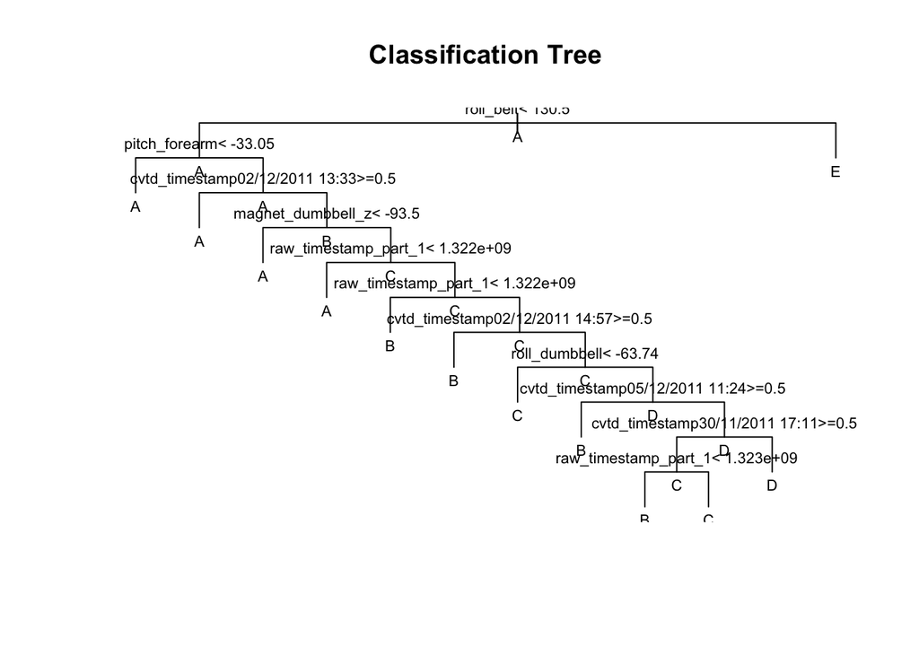

```r
plot(treefit$finalModel, uniform=TRUE, main="Classification Tree")
text(treefit$finalModel, all=TRUE, cex=0.7)
```

```r
sum(predict(treefit, newdata=testing)==testing$classe)/nrow(testing)
```

```
## [1] 0.6458794
```

### bagging

```r
treebag <- bag(training[,-57], training[,57], B=20,
               bagControl = bagControl(fit=ctreeBag$fit,
                                       predict=ctreeBag$pred,
                                       aggregate = ctreeBag$aggregate))
sum(predict(treebag$fits[[1]]$fit, testing[,-57]) == testing$classe)/nrow(testing)
```

```
## [1] 0.957689
```

We see that adding boostrap aggregation framework, we increase our accuracy to about 96%

### Random Forest

```r
rffit <- randomForest(classe ~ ., data=training)
sum(predict(rffit, testing[,-57]) == testing$classe)/nrow(testing)
```

```
## [1] 0.9993203
```

Random Forest further increase the prediction accuracy to 99.9%.

### Boosting

```r
boofit <- gbm(classe~., data = training,verbose = FALSE, interaction.depth = 3, shrinkage = 0.05, n.trees = 500)
```

```
## Distribution not specified, assuming multinomial ...
```

```r
pred <- predict(boofit,newdata =testing, n.trees = 500, type = "response")
predict <- apply(pred[,,1],1,function(x){
    colnames(pred[,,1])[x==max(x)]
})
sum(predict==testing$classe)/nrow(testing)
```

```
## [1] 0.997791
```

Boosting with each tree depth of 3, and shrink parameter 0.05 gives a final tree of 99.8% accuracy.  
Bagging, random forest, boosting all give a high accuracy tree!